# delta-s3

Created by: [Kumar N.P](https://www.linkedin.com/in/kumar-np)

### Delta Lake in AWS with Redshift Integration

##### (using AWS EMR, using AWS EMR, Apache Hive Warehouse (aka spark-warehouse) and AW S3)

Delta Lake brings ACID transactions to your data lakes. It provides serializability, the strongest level of isolation level.

Time Travel (data versioning):Delta Lake provides snapshots of data enabling developers to access and revert to earlier versions of data for audits, rollbacks or to reproduce experiments

Time travel in Delta improves developer productivity tremendously. It helps:

- Data scientists manage their experiments better
- Data engineers simplify their pipelines and roll back bad writes
- Data analysts do easy reporting

[figure not shown]

Apache Spark 3.0.and Delta Lake 0.7.0 onwards supporst registering and defining Delta-format tables in Hive Metastore

```python
from pyspark.sql import SparkSession
from pyspark.sql import SQLContext
from pyspark import SparkContext
from delta.tables import DeltaTable
import shutil # module offers a number of high-level operations on files and collections of files
from datetime import date # for date and time
import boto3 # to manage s3
```

```
Starting Spark application
```

| ID | YARN Application ID | Kind | State | Spark UI | Driver log | Current session? |
| --- | --- | --- | --- | --- | --- | --- |
| 75 | application_1604368822368_25850 | pyspark | idle |  |  | ✔ |

```
SparkSession available as 'spark'.
```

```python
import pandas as pd #convert sparkDF to pandasDF
from pyspark.sql.functions import col, expr #to run select on pandasDF

# Enable Arrow-based columnar data
spark.sql("SET spark.sql.execution.arrow.pyspark.enabled =true")
# OR
#spark.conf.set("spark.sql.execution.arrow.pyspark.enabled", "true")
```

```
DataFrame[key: string, value: string]
```

```python
# set Delta S3 path and table name/s

print("Set s3 bucket and Database")
dbName = "deltaDB"
bucketName = "deltalake-bucket"
delta_tbl_path = "s3a://deltalake-bucket/"
baseS3 = "deltas3"

#DB and table/s
dbName = "deltaDB"
tableName = "tbldelta"
col1 = "id"
deltaTabName = dbName +"."+ tableName
newTabName = "newData"
newTable = dbName+"."+newTabName
snapshotTable = "snapshot"
snapshotName =  dbName +"."+snapshotTable

print("Create s3 detlta folder")
# create s3 base folder object
s3 = boto3.client('s3')
bucket_name = bucketName
directory_name = "POC/" + baseS3 #name of new folder/s
s3.put_object(Bucket=bucket_name, Key=(directory_name+'/'))

# set miscellaneous variables
quotes = "'"
bkslash = "/"
delta_tble_s3_path =  "s3a://deltalake-bucket/" + directory_name
```

```
Set s3 bucket and Database
Create s3 detlta folder
```

```python
from datetime import datetime, date
now = datetime.now().time() # time object
today = date.today() # data object
```

```python
# Enable SQL/DML commands and Metastore tables for the current spark session.
spark = SparkSession \
  .builder \
  .config("spark.sql.extensions", "io.delta.sql.DeltaSparkSessionExtension") \
  .config("spark.sql.catalog.spark_catalog", "org.apache.spark.sql.delta.catalog.DeltaCatalog") \
  .config("spark.delta.logStore.class", "org.apache.spark.sql.delta.storage.S3SingleDriverLogStore") \
  .config("spark.delta.logStore.class", "org.apache.spark.sql.delta.storage.HDFSLogStore") \
  .getOrCreate()
```

```python
# Enable automatic schema evolution
spark.sql("SET spark.databricks.delta.schema.autoMerge.enabled = true")
```

```
DataFrame[key: string, value: string]
```

```python
# Drop database from pervious run
spark.sql("DROP DATABASE IF EXISTS {0} CASCADE".format(dbName))

# create new Database/schema
delta_db_loc = quotes+delta_tble_s3_path+bkslash+dbName+bkslash+quotes #set s3 location

print("----------Creating database:", dbName, "----------")
spark.sql("""CREATE DATABASE IF NOT EXISTS {0} LOCATION {1}
             COMMENT 'Contains delta tables'
             WITH DBPROPERTIES ('creator' = 'Kumar', 'date' = '{2}')"""
          .format(dbName, delta_db_loc, today))

#Display content of new database
spark.sql("DESCRIBE DATABASE EXTENDED {0}".format(dbName)).show(truncate=False)
```

```
----------Creating database: deltaDB ----------
+-------------------------+------------------------------------------+
|database_description_item|database_description_value                |
+-------------------------+------------------------------------------+
|Database Name            |deltadb                                   |
|Comment                  |Contains delta tables                     |
|Location                 |s3a://deltalake-bucket/POC/deltas3/deltaDB|
|Owner                    |livy                                      |
|Properties               |((date,2020-12-26), (creator,Kumar))      |
+-------------------------+------------------------------------------+
```

```python
# Create a delta table using SQL

print("############# Creating a table ###############")

#set s3 location
delta_tbl_loc = quotes+delta_tble_s3_path+bkslash+dbName+bkslash+tableName+bkslash+quotes

spark.sql("""CREATE TABLE IF NOT EXISTS {0}.{1} ({2} LONG) USING DELTA LOCATION {3}"""
          .format(dbName, tableName, col1, delta_tbl_loc))

spark.sql("SHOW TABLES FROM {} LIKE 'tbldelta*'".format(dbName)).show()

print("############# Insert values to table ###############")
spark.sql("INSERT INTO {0}.{1} VALUES 0, 1, 2, 3, 4".format(dbName, tableName))
```

```
############# Creating a table ###############
+--------+---------+-----------+
|database|tableName|isTemporary|
+--------+---------+-----------+
| deltadb| tbldelta|      false|
+--------+---------+-----------+

############# Insert values to table ###############
DataFrame[]
```

```python
# Read the table
print("############ Reading the table ###############")
spark.sql("SELECT * FROM {0} ORDER BY {1}".format(deltaTabName, col1)).show()
```

```
############ Reading the table ###############
+---+
| id|
+---+
|  0|
|  1|
|  2|
|  3|
|  4|
+---+
```

### Redshift Spectrum to Delta Lake integration

#### Amazon Redshift Spectrum adds support for querying open source Delta Lake

- We can now use Amazon Redshift to run read queries against tables in your Amazon S3 data lake with open source Delta Lake.
- Redshift Spectrum allows to read the latest snapshot Delta Lake (version 0.5.0 & 0.7.0) tables via the manifest files.

Refer to [`Creating external tables for Amazon Redshift Spectrum`](https://docs.aws.amazon.com/redshift/latest/dg/c-spectrum-external-tables.html)

##### Step 1 : Generate manifests of a Delta table using Apache Spark

```python
# Generate manifests of a Delta table using Apache Spark
spark.sql("GENERATE symlink_format_manifest FOR TABLE {0}".format(deltaTabName))
```

```
DataFrame[]
```

The generate operation generates manifest files at /_symlink_format_manifest/. In other words, the files in this directory contain the names of the data files (that is, Parquet files) that should be read for reading a snapshot of the Delta table.

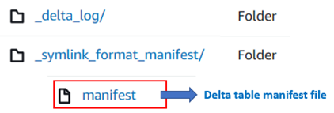

##### Step 2 : Create Redshift external table

CREATE EXTERNAL TABLE spectrum_delta.tbldelta_spectrum (id BIGINT)  
ROW FORMAT SERDE 'org.apache.hadoop.hive.ql.io.parquet.serde.ParquetHiveSerDe'  
STORED AS  
INPUTFORMAT 'org.apache.hadoop.hive.ql.io.SymlinkTextInputFormat'  
OUTPUTFORMAT 'org.apache.hadoop.hive.ql.io.HiveIgnoreKeyTextOutputFormat'  
LOCATION 's3://bucket-name/POC/deltas3/deltaDB/tbldelta/_symlink_format_manifest/';

##### Query Redshift external delta table

The query results from Redshift spectrum external table should be same as above delta table

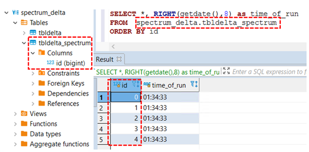

```python
# Upsert (merge) new data

print("############# Creating a newData table ###############")
# newData table s3 location
newData_loc = quotes+delta_tble_s3_path+bkslash+dbName+bkslash+newTabName+bkslash+quotes

spark.sql("CREATE TABLE IF NOT EXISTS {0} ({1} LONG) USING parquet LOCATION {2}"
          .format(newTable, col1, newData_loc))

spark.sql("SHOW TABLES FROM {} LIKE 'newData'".format(dbName)).show()

print("############# Insert values to table ###############")
spark.sql("INSERT INTO {0} VALUES 3, 4, 5, 6".format(newTable))

print("########### Upsert new data #############")
spark.sql('''MERGE INTO {0} USING {1}
            ON {0}.id = {1}.{2}
            WHEN MATCHED THEN
              UPDATE SET {0}.{2} = {1}.{2}
            WHEN NOT MATCHED THEN INSERT *
        '''.format(deltaTabName, newTable, col1))

print("########### view upsert data #############")
spark.sql("SELECT * FROM {0} ORDER BY {1}".format(deltaTabName, col1)).show()
```

```
############# Creating a newData table ###############
+--------+---------+-----------+
|database|tableName|isTemporary|
+--------+---------+-----------+
| deltadb|  newdata|      false|
+--------+---------+-----------+

############# Insert values to table ###############
########### Upsert new data #############
########### view upsert data #############
+---+
| id|
+---+
|  0|
|  1|
|  2|
|  3|
|  4|
|  5|
|  6|
+---+
```

##### Check if the Redshift spectrum external table shows same result as above

`The manifest file created in the previous steps doesn't reflect the recent “upsert/merge” or "insert overwrite" transactions` `The select query on Redshift external table still shows old values as shown below:`

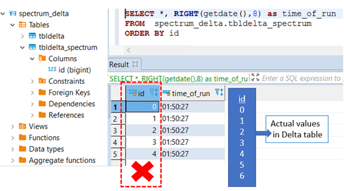

### Update manifests

##### When the data in a Delta table is updated you must regenerate the manifests using either of the following approaches:

> - **Update explicitly:** After all the data updates, you can run the `generate` operation to update the manifests.
> - **Update automatically:** You can configure a Delta table so that all write operations on the table automatically update the manifests. To enable this automatic mode, set the corresponding table property using the following SQL command.

The Redshift Spectrum integration has known limitations in its behavior on the mainfest file

Whenever Delta Lake generates updated manifests, it atomically overwrites existing manifest files. Therefore, Redshift Spectrum will always see a consistent view of the data files; it will see all of the old version files or all of the new version files. However, the granularity of the consistency guarantees depends on whether the table is partitioned or not.

- Refer to [Redshift Spectrum Delta lake Limitations](https://docs.databricks.com/delta/redshift-spectrum-integration.html#limitations)
- Refer to [Limitations and troubleshooting for Delta Lake tables](https://docs.aws.amazon.com/redshift/latest/dg/c-spectrum-external-tables.html)

```python
# Update manifest
spark.sql("""ALTER TABLE {0}
          SET TBLPROPERTIES(delta.compatibility.symlinkFormatManifest.enabled=true)"""
          .format(deltaTabName)).show()
```

```
++
||
++
++
```

```python
# Update table data

print("########## Overwrite the table : ", deltaTabName, " ###########")
## The INSERT OVERWRITE overwrites the existing data in the table or its partiton using the
#new values.The inserted rows can be specified by value expressions or result from a query.
spark.sql("INSERT OVERWRITE {0} select * FROM (VALUES 5, 6, 7, 8, 9) x ({1})"
          .format(deltaTabName, col1))

# Query the table to view insert overwrtie
spark.sql("SELECT * FROM {0} ORDER BY {1}".format(deltaTabName, col1)).show()
```

```
########## Overwrite the table :  deltaDB.tbldelta  ###########
+---+
| id|
+---+
|  5|
|  6|
|  7|
|  8|
|  9|
+---+
```

##### Query Redshift spectrum external table to check if above results are reflected

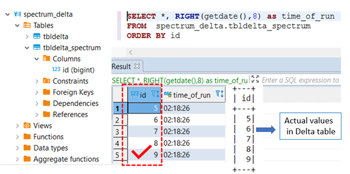

Depending on what storage system you are using for Delta tables, it is possible to get incorrect results when Redshift Spectrum concurrently queries the manifest while the manifest files are being rewritten. In file system implementations that lack atomic file overwrites, a manifest file may be momentarily unavailable. Hence, use manifests with caution if their updates are likely to coincide with queries from Redshift Spectrum

**Performance**

This is an experimental integration and its performance and scalability characteristics have not yet been tested.

```python
# Update every even value by adding 100 to it
print("########### Update to the table(add 100 to every even value) ##############")
spark.sql("UPDATE {0} SET id = ({1} + 100) WHERE ({1} % 2 == 0)".format(deltaTabName, col1))
spark.sql("SELECT * FROM {0} ORDER BY {1}".format(deltaTabName, col1)).show()
```

```
########### Update to the table(add 100 to every even value) ##############
+---+
| id|
+---+
|  5|
|  7|
|  9|
|206|
|208|
+---+
```

```python
spark.sql("SELECT * FROM {0} ORDER BY {1}".format(deltaTabName, col1)).show()
```

```
+---+
| id|
+---+
|  5|
|  7|
|  9|
|206|
|208|
+---+
```

```python
# Delete records with even value
print("######### Delete every even value ##############")
spark.sql("DELETE FROM {0} WHERE ({1} % 2 == 0)".format(deltaTabName,col1))
spark.sql("SELECT * FROM {0} ORDER BY {1}".format(deltaTabName, col1)).show()
```

```
######### Delete every even value ##############
+---+
| id|
+---+
|  5|
|  7|
|  9|
+---+
```

```python
# DESCRIBE HISTORY retrieves information on the operations, user, timestamp, and so on
# for each write to a Delta table by running the history command.
# The operations are returned in reverse chronological order.

# By default table history is retained for 30 days.
#spark.sql("DESCRIBE HISTORY %s" % tableName).show(truncate=False, vertical=True)
df_Hist = spark.sql("DESCRIBE HISTORY %s" % deltaTabName)
df_Hist.select("version", "timestamp", "operation", "operationParameters",
               "readVersion", "operationMetrics").show() #selective columns out of 14 columns
```

```
+-------+-------------------+-----------------+--------------------+-----------+--------------------+
|version|          timestamp|        operation| operationParameters|readVersion|    operationMetrics|
+-------+-------------------+-----------------+--------------------+-----------+--------------------+
|      7|2020-12-26 13:30:36|           DELETE|[predicate -> ["(...|          6|[numRemovedFiles ...|
|      6|2020-12-26 13:27:29|           UPDATE|[predicate -> ((i...|          5|[numRemovedFiles ...|
|      5|2020-12-26 13:25:13|           UPDATE|[predicate -> ((i...|          4|[numRemovedFiles ...|
|      4|2020-12-26 13:18:14|            WRITE|[mode -> Overwrit...|          3|[numFiles -> 5, n...|
|      3|2020-12-26 12:55:48|SET TBLPROPERTIES|[properties -> {"...|          2|                  []|
|      2|2020-12-26 12:48:47|            MERGE|[predicate -> (sp...|          1|[numTargetRowsCop...|
|      1|2020-12-26 11:00:48|            WRITE|[mode -> Append, ...|          0|[numFiles -> 4, n...|
|      0|2020-12-26 11:00:21|     CREATE TABLE|[isManaged -> fal...|       null|                  []|
+-------+-------------------+-----------------+--------------------+-----------+--------------------+
```

##### When a total of 10 transactions are committed to the transaction log, Delta Lake saves a checkpoint file in Parquet format in the same _delta_log subdirectory. Delta Lake automatically generates checkpoint files every 10 commits.

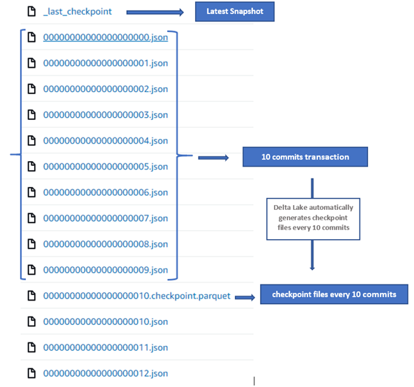

```python
# Get lastest version of delta table into a variable
latest_ver = df_Hist.agg({'version': 'max'}).collect()[0][0]

print("Latest of delta-table:", deltaTabName, "is version: ", latest_ver)
```

```
Latest of delta-table: deltaDB.tbldelta is version:  7
```

```python
# retrieve latest information on the operations via datafram
deltaTable = DeltaTable.forName(spark, deltaTabName)
lastOperationDF = deltaTable.history(1) # retrives latest operation
lastOperationDF.show(truncate=False, vertical=True)
```

```
-RECORD 0--------------------------------------------------------------------------------------------------
 version             | 7
 timestamp           | 2020-12-26 13:30:36
 userId              | null
 userName            | null
 operation           | DELETE
 operationParameters | [predicate -> ["((spark_catalog.deltaDB.tbldelta.`id` % 2L) = 0L)"]]
 job                 | null
 notebook            | null
 clusterId           | null
 readVersion         | 6
 isolationLevel      | null
 isBlindAppend       | false
 operationMetrics    | [numRemovedFiles -> 2, numDeletedRows -> 2, numAddedFiles -> 1, numCopiedRows -> 0]
 userMetadata        | null
```

```python
spark.sql("SHOW TABLES FROM deltadb").show(truncate=False)
```

```
+--------+-----------------+-----------+
|database|tableName        |isTemporary|
+--------+-----------------+-----------+
|deltadb |newdata          |false      |
|deltadb |tbldelta         |false      |
|deltadb |tbldelta_spectrum|false      |
+--------+-----------------+-----------+
```

```python
# Read old version of data using time travel into a dataframe
# Using this option data can be restored to orginal table or restored to a new table
print("######## Read old data using time travel variable ############")

#### --------------- Data frame ---------------
#df = spark.read.format("delta").option("versionAsOf", 1).table(tableName) # .table doesn't work in EMR
#df = spark.read.format("delta").option("versionAsOf", 1).load("s3a://POC/deltas3/deltaDB/tbldelta/")
#df.orderBy("id").show(truncate=False)
#### ------------------------------------------

#OR use below SQL to view and load old version of data
#build time trave variable
timeTravel ="`"+delta_tbl_loc[1:-1]+"@v1"+"`" # var[1:-1] strips first and last quotes
spark.sql("SELECT * FROM delta.{0} ORDER BY {1}".format(timeTravel, col1)).show()
```

```
######## Read old data using time travel variable ############
+---+
| id|
+---+
|  0|
|  1|
|  2|
|  3|
|  4|
+---+
```

```python
# do dry run to get the list of files to be deleted

spark.sql("VACUUM %s DRY RUN" %deltaTabName).show(truncate=False)

#OR

vcum_tbl_loc = "`"+delta_tbl_loc[1:-1]+"`"
#spark.sql("VACUUM delta.{0} DRY RUN".format(vcum_tbl_loc)).show(truncate=False)

# if the list is empty than there are no files to be deleted
```

```
+----+
|path|
+----+
+----+
```

```python
# VACCUM remove files no longer referenced by a Delta table and are older than the
# retention threshold.The default retention threshold for the files is 7 days.
spark.sql("VACUUM %s" %deltaTabName).show(truncate=False)

# Note : The ability to time travel back to a version older than the retention period is
# lost after running vacuum.

# Delta Lake has a safety check to prevent you from running a dangerous vacuum command.
# If you are certain that there are no operations being performed on this table that take longer
# than the retention interval you plan to specify, you can turn off this safety check by setting
# the Apache Spark configuration property spark.databricks.delta.retentionDurationCheck.enabled to false.
# You must choose an interval that is longer than the longest running concurrent transaction and
# the longest period that any stream can lag behind the most recent update to the table.
```

```
+---------------------------------------------------+
|path                                               |
+---------------------------------------------------+
|s3a://deltalake-bucket/POC/deltas3/deltaDB/tbldelta|
+---------------------------------------------------+
```

### Delta time-travel for large scale datalakes

#### Continuously updating Delta table across multiple downstream jobs

##### Pinned view of a continuously updating Delta table across multiple downstream jobs

With VERSION queries, we can now pin the snapshot of a continuously updating Delta table for multiple downstream jobs. Consider a situation where a Delta table is being continuously updated, say every 15 seconds, and there is a downstream job that periodically reads from this Delta table and updates different destinations. In such scenarios, typically we want a consistent view of the source Delta table so that all destination tables reflect the same state. We can now easily handle such scenarios as follows:

```python
# Get recent snapshot version (i.e. lastest minus 1) of delta table into a variable
recent_ver = str((df_Hist.agg({'version': 'max'}).collect()[0][0]-1)) #convert to str
recent_ver = "`"+delta_tbl_loc[1:-1]+ "@v"+recent_ver+"`"

snapData_loc = quotes+delta_tble_s3_path+bkslash+dbName+bkslash+snapshotTable+bkslash+quotes

# Create df for recent snapshot
df_recent = spark.sql("SELECT * FROM delta.{0} ORDER BY {1}".format(recent_ver, col1))

# Register table so it is accessible via SQL Context
df_recent.createOrReplaceTempView("df_recent")

# Drop snapshot tables from pervious run
df_drop = spark.sql("SHOW TABLES IN {0} LIke '{1}*'"
                    .format(dbName, snapshotTable)).select("database","tableName")

rownum=0
for t in df_drop.collect():
    dropTable = (t.database+"."+t.tableName)
    rownum= rownum + 1
    rownumSTR= str(rownum)
    rownumSTR = "["+rownumSTR+"]."
    print(rownumSTR, "Dropping table:", dropTable)
    spark.sql("DROP TABLE IF EXISTS {0}".format(dropTable))

# Create a new snapshot table/s for each unique values

# newData table s3 location
snapData_loc = quotes+delta_tble_s3_path+bkslash+dbName+bkslash+snapshotTable+bkslash+quotes

print("--------------------Create snapshot table/s --------------------")
for i in df_recent.collect():
    snapData_loc_n = "`"+snapData_loc[1:-1]+snapshotTable+str(i.id)+bkslash+"`"
    print("create and populate sanpshot table :",snapshotName+str(i.id))
    spark.sql('''CREATE TABLE IF NOT EXISTS {0} STORED AS PARQUET LOCATION {1}
                 AS SELECT * FROM df_recent WHERE {2} == {3}'''
              .format(snapshotName+str(i.id), snapData_loc, col1, (i.id)))

# query Snapshot tables
df_snapshot = spark.sql("SHOW TABLES IN {0} LIke '{1}*'"
                    .format(dbName, snapshotTable)).select("database","tableName")

print("--------------------Query snapshot table/s --------------------")
sqlSTRNew = ''
strUNION = " UNION "
counter=1
RowsNo=df_snapshot.count()

for s in df_snapshot.collect():
    pinTable = s.database + "." + s.tableName
    sqlSTR=("""SELECT '{0}' AS database, '{1}' AS tablName, count({2}) AS rowCount FROM {3}"""
         .format(s.database, s.tableName, col1, pinTable))
    if counter == RowsNo:
      sqlSTRNew = sqlSTRNew +  sqlSTR
    else:
        sqlSTRNew =sqlSTRNew +  sqlSTR + strUNION
    counter = counter+1

# execute SQL
spark.sql(sqlSTRNew).show()
```

```
--------------------Create snapshot table/s --------------------
create and populate sanpshot table : deltaDB.snapshot5
create and populate sanpshot table : deltaDB.snapshot7
create and populate sanpshot table : deltaDB.snapshot9
create and populate sanpshot table : deltaDB.snapshot206
create and populate sanpshot table : deltaDB.snapshot208
--------------------Query snapshot table/s --------------------
+--------+-----------+--------+
|database|   tablName|rowCount|
+--------+-----------+--------+
| deltadb|snapshot208|       1|
| deltadb|  snapshot7|       1|
| deltadb|  snapshot9|       1|
| deltadb|snapshot206|       1|
| deltadb|  snapshot5|       1|
+--------+-----------+--------+
```

#### Both delta table mapped to manifest file and regular tables can be accessed via Redshift Spectrum

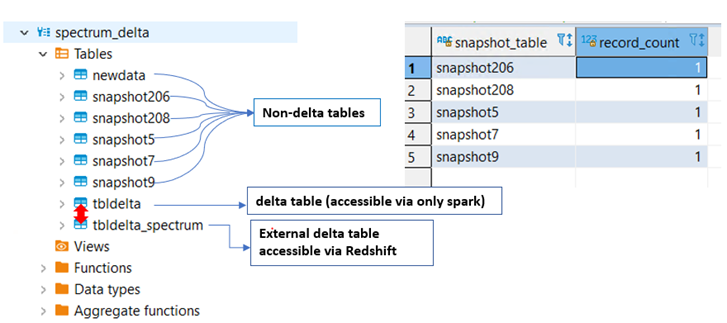

```python
# cleanup

# Drop table
# spark.sql ("DROP TABLE IF EXISTS {0}.{1}".format(dbName, tableName))
#--------------------------------------------------
# Manually remove the S3 folder of unmanaged tables
#--------------------------------------------------
# Tables created with a specified LOCATION are considered unmanaged by the metastore.
# Unlike a managed table, where no path is specified, an unmanaged table’s files are not deleted
# when you DROP the table. These folders in S3 have to be manually removed as below:

## Run below only if you drop tables
# s3 = boto3.resource('s3')
# bucket = s3.Bucket('deltalake-bucket')
# bucket.objects.filter(Prefix="POC/deltas3/tbldelta/").delete() #folder to be removed

# Drop database
# Drops a database and deletes the directory associated with the database from the file system.
# An exception is thrown if the database does not exist in the system.

spark.sql("DROP DATABASE IF EXISTS {0} CASCADE".format(dbName))

# Manually remove the S3 folder used for demo
s3 = boto3.resource('s3')
bucket = s3.Bucket('deltalake-bucket')
bucket.objects.filter(Prefix="POC/deltas3/").delete() #folder to be removed is "PO" & deltas3". Run with caution!!!
```

Created by: [Kumar N.P](https://www.linkedin.com/in/kumar-np)